# Investigating Soil Series Extent

D.E. Beaudette

2026-03-03

# Introduction

# Installation

With a recent version of R, it should be possible to get all of the packages that this tutorial depends on via:

```r
# run these commands in the R console to install required packages
install.packages('soilDB', dep=TRUE)
install.packages('terra', dep=TRUE)
install.packages('sf', dep=TRUE)
install.packages('maps', dep=TRUE)
install.packages('scales', dep=TRUE)
install.packages('mapview', dep=TRUE)
```

# Examples

Illustrate the extent of SSURGO map units associated with the Amador series.

```r
# load required libraries
library(soilDB)
library(sf)
library(terra)
library(maps)
library(rasterVis)
```

Investigate the structure of soil series extent data.

```r
# the result is an af object
amador <- seriesExtent('amador')

# internal structure / class
class(amador)
```

```
## [1] "sf"         "data.frame"
```

```r
# coordinate reference system in PROJ4 notation
st_crs(amador)
```

```
## Coordinate Reference System:
##   User input: WGS 84
##   wkt:
## GEOGCRS["WGS 84",
##     DATUM["World Geodetic System 1984",
##         ELLIPSOID["WGS 84",6378137,298.257223563,
##             LENGTHUNIT["metre",1]]],
##     PRIMEM["Greenwich",0,
##         ANGLEUNIT["degree",0.0174532925199433]],
##     CS[ellipsoidal,2],
##         AXIS["geodetic latitude (Lat)",north,
##             ORDER[1],
##             ANGLEUNIT["degree",0.0174532925199433]],
##         AXIS["geodetic longitude (Lon)",east,
##             ORDER[2],
##             ANGLEUNIT["degree",0.0174532925199433]],
##     ID["EPSG",4326]]
```

```r
# check attribute table, details: http://casoilresource.lawr.ucdavis.edu/see/
head(amador)
```

```
## Simple feature collection with 1 feature and 4 fields
## Geometry type: MULTIPOLYGON
## Dimension:     XY
## Bounding box:  xmin: -121.193 ymin: 37.183 xmax: -120.078 ymax: 38.588
## Geodetic CRS:  WGS 84
##        series acres gridsize    n                       geometry
## AMADOR AMADOR 48797    0.001 1227 MULTIPOLYGON (((-121.024 38...
```

## Compare Amador, Pardee, and San Joaquin Extents

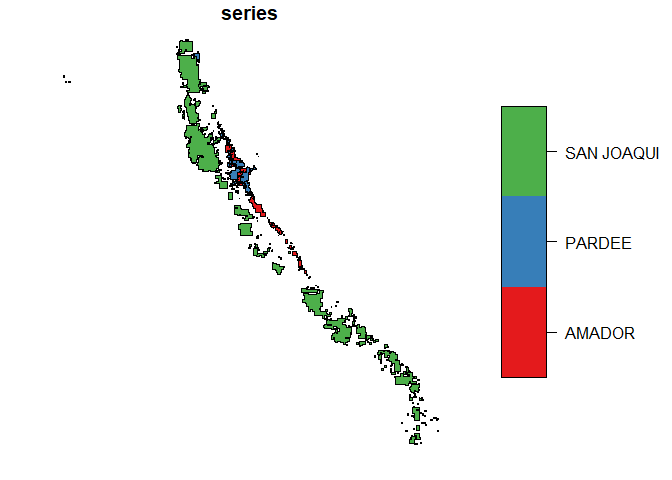

```r
# soil series of interest
s <- c('amador', 'pardee', 'san joaquin')

# define some nice colors
cols <- c("#E41A1C", "#377EB8", "#4DAF4A")

# iterate over vector of soil series names
# and store spatial extents in a list
s.extent <- lapply(s, seriesExtent, timeout = 120)

# combine into a single sf object
s.extent <- do.call('rbind', s.extent)

# very simple plot method for sf objects
# https://r-spatial.github.io/sf/articles/sf5.html
plot(s.extent['series'], axes = FALSE, key.width = lcm(4.5), pal = cols)
```

## Interactive mapping from R

This is based on the [mapview](https://r-spatial.github.io/mapview/) package.

```r
library(mapview)
mapview(s.extent, zcol = 'series', legend = TRUE)
```

[interactive chart not shown]

## Exporting Series Extent Data

Save soil series extent data in multiple formats.

```r
# save using the coordinate reference system associated with this object (GCS WGS84)
write_sf(s.extent, dsn = 'amador-pardee-san-joaquin-extent.shp')

# save as KML for use in Google Earth
# writeOGR(s.extent, dsn='amador-pardee-san-joaquin-extent.kml', layer='amador-pardee-san-joaquin', driver='KML')

# project to UTM zone 10 NAD83 and save
# s.extent.utm <- spTransform(s.extent, CRS('+proj=utm +zone=10 +datum=NAD83'))
# writeOGR(s.extent.utm, dsn='.', layer='amador-pardee-san-joaquin-extent-utm', driver='ESRI Shapefile')
```

# Graphical Display of Joint Series Extent

Using vector features, works with all SSURGO data.

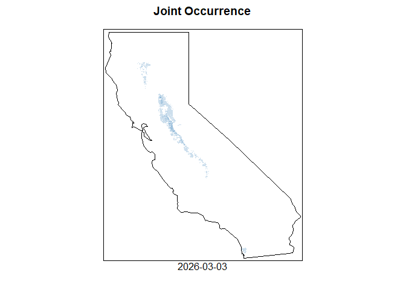

```r
# need this for alpha()
library(scales)

# define some nice colors
cols <- c("#E41A1C", "#377EB8", "#4DAF4A")

# list of series for investigation of joint occurrence
s <- c('pentz', 'peters', 'pardee', 'amador', 'san joaquin', 'redding', 'auburn')

# get list of extents
e <- lapply(s, seriesExtent)

# flatten to single sf object
e <- do.call('rbind', e)

# map of CA
par(mar = c(1,1,1,1))
map('state', 'ca')

# sf plot method
# polygon extents are "stacked" with transparency
plot(st_geometry(e), border = NA, col = alpha(cols[2], 0.25), add = TRUE)

# finish map
box()
title(main = 'Joint Occurrence', line = 1.25)
mtext(side = 1, text = as.character(Sys.Date()), line = 0)
```

Join occurrence of Zook and siblings.

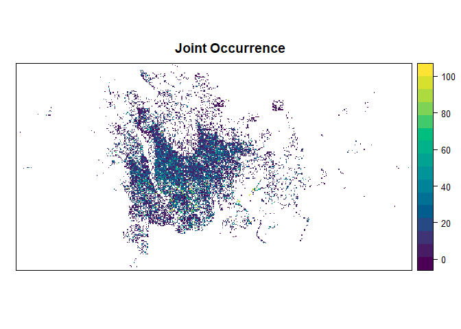

```r
# using all siblings of a given soil series
s <- 'zook'
sib <- siblings(s)
sib.names <- c(s, sib$sib$sibling)

# get list of series extent grids
# note these all have different bounding-boxes (raster extents)
g <- lapply(sib.names, function(i) {
  se <- suppressWarnings(seriesExtent(i, type = 'raster'))
  # threshold at 15%
  # se <- se >= 15

  return(se)
})


# assemble collection, 44 spatRast objects
g <- sprc(g)

# merge into single SpatRaster
# compute sum whenever there is overlap
m <- mosaic(g, fun = 'sum')

# values > 100% are rounding errors
# truncate at 100%
m[m > 100] <- 100

levelplot(
  m,
  col.regions = hcl.colors,
  main = 'Joint Occurrence',
  margin = FALSE,
  scales = list(draw = FALSE)
)
```

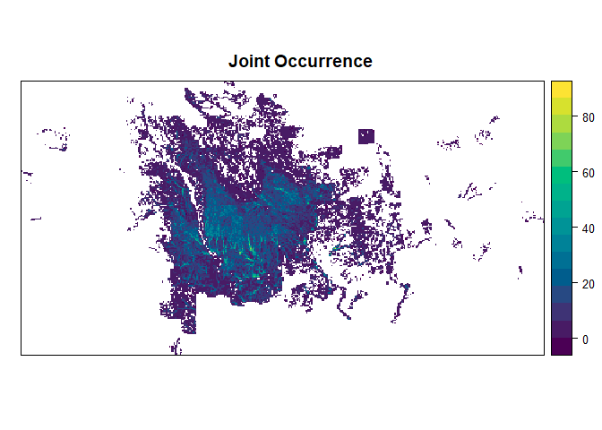

```r
# generalize via focal sum
a <- aggregate(m, fact = 5, fun = sum, na.rm = TRUE)

# re-scale to fractions of 5x larger grid size
a <- a / 5^2

levelplot(
  a,
  col.regions = hcl.colors,
  main = 'Joint Occurrence',
  margin = FALSE,
  scales = list(draw = FALSE)
)
```

# Boomer Soil Series Extent

Lets investigate the spatial extent and MLRA overlap for the [Boomer](http://casoilresource.lawr.ucdavis.edu/sde/?series=boomer) soil series. We will use the SoilWeb SEE data for an estimate of the spatial extent and [Soil Data Access](http://ncss-tech.github.io/AQP/soilDB/SDA-tutorial.html) for MLRA overlap information.

Get extent and make a simple map.

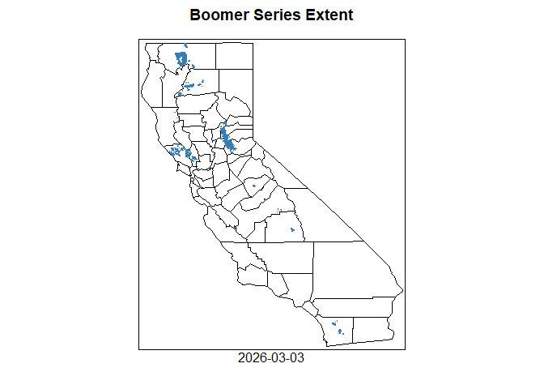

```r
# define some nice colors
cols <- c("#E41A1C", "#377EB8", "#4DAF4A")

# get extent
boomer <- seriesExtent('boomer')

# basic figure
par(mar=c(1,0,1,0))
map(database='county', regions='california')
plot(st_geometry(boomer), col=cols[2], border=cols[2], add=TRUE)
box()
title(main='Boomer Series Extent', line=1.25)
mtext(side=1, text=as.character(Sys.Date()), line=0)
```

Investigate MLRA overlap for the Boomer series via [SDA](http://ncss-tech.github.io/AQP/soilDB/SDA-tutorial.html) (official SSURGO data). These results are based on the assumption that the “muaoverlap” table is correctly populated.

```r
res <- SDA_query("SELECT compname, areasymbol as mlra, areaname as mlra_name, count(compname) as n_components from laoverlap JOIN muaoverlap ON laoverlap.lareaovkey = muaoverlap.lareaovkey JOIN component ON muaoverlap.mukey = component.mukey WHERE compname = 'boomer' AND areatypename = 'MLRA' GROUP BY compname, areasymbol, areaname ORDER BY count(compname) DESC")
knitr::kable(res, row.names = FALSE)
```

| compname | mlra | mlra_name | n_components |
| --- | --- | --- | --- |
| Boomer | 22A | Sierra Nevada and Tehachapi Mountains | 71 |
| Boomer | 5 | Siskiyou-Trinity Area | 66 |
| Boomer | 15 | Central California Coast Range | 48 |
| Boomer | 18 | Sierra Nevada Foothills | 44 |
| Boomer | 22A | Sierra Nevada Mountains | 18 |
| Boomer | 22B | Southern Cascade Mountains | 14 |
| Boomer | 14 | Central California Coastal Valleys | 13 |
| Boomer | 4B | Coastal Redwood Belt | 11 |
| Boomer | 17 | Sacramento and San Joaquin Valleys | 10 |
| Boomer | 21 | Klamath and Shasta Valleys and Basins | 6 |
| Boomer | 31 | Lower Colorado Desert | 2 |
| Boomer | 20 | Southern California Mountains | 2 |

That seems strange, which map units are in MLRA 31?

```r
res <- SDA_query("SELECT component.mukey, muname, compname, comppct_r from laoverlap JOIN muaoverlap ON laoverlap.lareaovkey = muaoverlap.lareaovkey JOIN mapunit ON muaoverlap.mukey = mapunit.mukey JOIN component ON muaoverlap.mukey = component.mukey WHERE compname = 'boomer' AND areatypename = 'MLRA' AND areasymbol = '31'")
knitr::kable(res, row.names = FALSE)
```

| mukey | muname | compname | comppct_r |
| --- | --- | --- | --- |
| 660462 | Hotaw-Crouch-Boomer (s1015) | Boomer | 1 |
| 660462 | Hotaw-Crouch-Boomer (s1015) | Boomer | 15 |

This document is based on `aqp` version 2.3.1, `soilDB` version 2.9.0 and `terra` version 1.8-97.